# MSDS 6306: Unit 3 Assignment

James Harding - Section 401

9/10/2018

## 1. GitHub Cloning

Using Git, clone the following GitHub repository to your local machine: https://github.com/caesar0301/awesome-public-datasets. In RMarkdown, please show the code (commented out, as it’s not R syntax) that you used to create a new directory, navigate to the appropriate directory, and clone the repository to it. One Git command per line, please.

I currently have a directory on my laptop where I store all of my repositories. I have a private repository just for school work located at `/Users/jharding/repos/SMU`. Withing this directory, I also have additional folders that contain repositories. For those folders, I make sure to include them in my `.gitignore`. I will not create a new folder but will change directories and to my main repository directory and clone from there. I’ll use the `system()` function to do both.

```
#################################################################
## Used the following R code to play around creating directories
## and cloning repositories
#################################################################

   ######################################################
   ### Variables to set the directories and naming
   ######################################################
   repodir <- "/Users/jharding/repos/SMU"
   newrep <- "awesome-public-datasets"
   setwd(repodir)
   gitignore <-system("cat .gitignore |grep awesome-public-datasets", intern = TRUE)
   gitignore <-system("cat .gitignore", intern = TRUE)
   gitignore

   ######################################################
   ## My root directory "/Users/jharding/repos/SMU" is
   ## a git repository.  I need to add the new directories
   ## to my .gitignore.  I nest my repositories under this
   ## directory
   ######################################################
   gitignore <-system("cat .gitignore", intern = TRUE)
   if (any(grepl(newrep, gitignore))) {
     system("tail -3 .gitignore")
   } else {
     system("echo awesome-public-datasets >> .gitignore")
     gitignore <-system("cat .gitignore", intern = TRUE)
   }

  ######################################################
  ## Clone the repository
  ######################################################
  system("cd /Users/jharding/repos/SMU; git clone https://github.com/caesar0301/awesome-public-datasets", intern = TRUE)
```

## 2. Data Summary

### 2a.

In R, please read in titanic.csv via either read.table() or read.csv(), assigning it to df. This dataset follows the passengers aboard the Titanic, including their fees paid, rooms rented, and survivorship status.

```
  ######################################################
  ## Unzip titanic.csv.zip
  ######################################################
  setwd("/Users/jharding/repos/SMU/awesome-public-datasets")
  system("unzip Datasets/titanic.csv.zip")

  ######################################################
  ## Clean-up after unzipping
  ######################################################
  system("mv titanic.csv Datasets/.")
  system("rmdir __MACOSX")
```

```r
######################################################
## Create dataframe:
######################################################

## Set working directory and read in csv
  #setwd("/Users/jharding/repos/SMU/awesome-public-datasets")
  file <- "/Users/jharding/repos/SMU/awesome-public-datasets/Datasets/titanic.csv"
  df.titanic <- read.csv(file, header=TRUE, sep=",")
```

### 2b.

Output the respective count of females and males aboard the Titanic. Plot the frequency of females and males. Be sure to give an accurate title and label the axes.

```r
### Output respective counts

sex.freq <- df.titanic %>%
  group_by(Sex) %>%
  summarise(counts = n())

sex.freq <- sex.freq %>%
  arrange(desc(Sex)) %>%
  mutate(PctOfSex = round(counts*100/sum(counts),2))

sex.freq
```

```
## # A tibble: 2 x 3
##   Sex    counts PctOfSex
##   <fct>   <int>    <dbl>
## 1 male      577     64.8
## 2 female    314     35.2
```

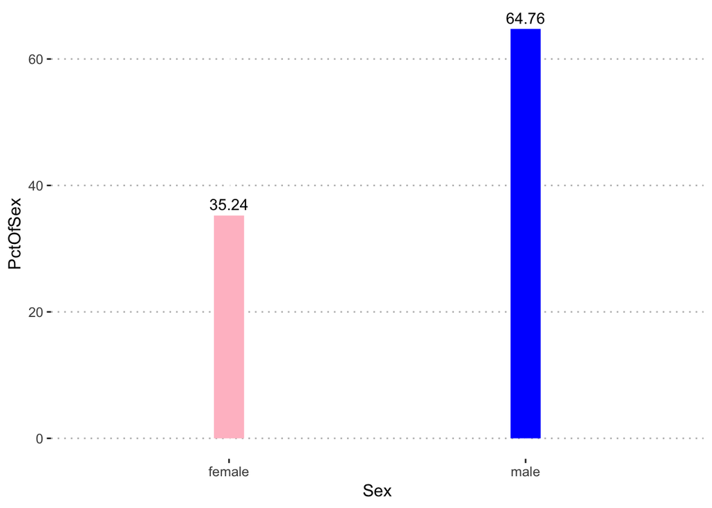

```r
ggplot(sex.freq, aes(Sex, PctOfSex)) +
  geom_linerange(
    aes(x = Sex, ymin=0, ymax = PctOfSex),
    color = c("blue","pink"), size = 10
  ) +
  geom_text(aes(label = PctOfSex), vjust = -.5) +
  theme_pubclean()
```

### 2c.

Please use one apply function (to review: swirl() modules 11, 12) to output the means of Age, Fare, and Survival. Make sure the output is a real number for all three means.

```r
## Select columns by name using the dplyr() library

mean.age <- mean(df.titanic$Age, na.rm=TRUE)
mean.fare <- mean(df.titanic$Fare, na.rm=TRUE)
mean.survived <- mean(df.titanic$Survived, na.rm=TRUE)

paste("Values should be:", sep="")
```

```
## [1] "Values should be:"
```

```r
paste("Mean.Age = ", round(mean.age, 4), "   Mean.Fare = ", round(mean.fare,4), "   Mean.Survived = ", round(mean.survived,4), sep="")
```

```
## [1] "Mean.Age = 29.6991   Mean.Fare = 32.2042   Mean.Survived = 0.3838"
```

```r
## Use lapply() to calculate the means
lapply(select(df.titanic, one_of(c("Age","Fare","Survived"))), function(x) mean(x,na.rm=TRUE))
```

```
## $Age
## [1] 29.69912
##
## $Fare
## [1] 32.20421
##
## $Survived
## [1] 0.3838384
```

## 3. Function Building

You research sleep and just got your first data set. Later, you’ll have another dataset with the same column names, so you want to create a helper function that you can analyze this dataset and the next. Load sleep_data_01.csv (found at http://talklab.psy.gla.ac.uk/L1_labs/lab_1/homework/index.html). Questions 3A through 3D should be answered in function(x){}.

```r
## Load Sleep Study Data
df.SleepData <- read.csv("http://talklab.psy.gla.ac.uk/L1_labs/lab_1/homework/sleep_data_01.csv")
```

### 3a / b

- Create objects for the median Age, the minimum and maximum Duration of sleep, and the mean and standard deviation of the Rosenberg Self Esteem scale (RSES).
- Create a data.frame object called report: it should consist of the median age, the RSES mean and standard deviation respectively divided by five (since there are five questions and these scores are summed), and the range of Duration (the statistical definition of range; it should be a single number.
- Change the column names of this data.frame to MedianAge, SelfEsteem, SE_SD, and DurationRange.
- Round the report to at most 2 digits: leave this as the closing line to the function.
- Finally, run the function on your sleep data to show the output.

```r
sleep.summary <- function(a){

  a.median <- median(a$Age, na.rm = TRUE)
  a.min <- min(a$Duration, na.rm = TRUE)
  a.max <- max(a$Duration, na.rm = TRUE)
  a.mean <- mean(a$RSES, na.rm = TRUE)
  a.sd <- sd(a$RSES, na.rm = TRUE)

  report <- data.frame(a.median, a.mean, a.sd/5, (a.max - a.min))

  colnames(report) <- c("MedianAge", "SelfEsteem", "SE_SD", "DurationRange")

  round(report,2)
}

sleep.summary(df.SleepData)
```

```
##   MedianAge SelfEsteem SE_SD DurationRange
## 1        14      18.11  1.24             7
```

## 4. FiveThirtyEight Data

- In the listing of Data sets in package ‘fivethirtyeight,’ assign the 22nd data set to an object ‘df.’
- Use a more detailed list of the data sets to write out the URL in a comment to the related news story.

```r
##

dsets <- data(package = "fivethirtyeight")$result[, "Item"]
head(dsets[22])
```

```
## [1] "college_recent_grads"
```

```r
df <- fivethirtyeight::college_recent_grads

data(package = "fivethirtyeight")
```

- Using R command(s), give the dimensions and column names of this data frame.

```r
dim(df)
```

```
## [1] 173  21
```

## 5.Data Summary

Use your newly assigned data frame from question 4 for this question.

### 5a.

```r
names(df)
```

```
##  [1] "rank"                        "major_code"
##  [3] "major"                       "major_category"
##  [5] "total"                       "sample_size"
##  [7] "men"                         "women"
##  [9] "sharewomen"                  "employed"
## [11] "employed_fulltime"           "employed_parttime"
## [13] "employed_fulltime_yearround" "unemployed"
## [15] "unemployment_rate"           "p25th"
## [17] "median"                      "p75th"
## [19] "college_jobs"                "non_college_jobs"
## [21] "low_wage_jobs"
```

### 5b.

Generate a count of each unique major_category in the data frame. I recommend using libraries to help. To be clear, this should look like a matrix or data frame containing the major_category and the frequency it occurs in the dataset. Assign it to major_count.

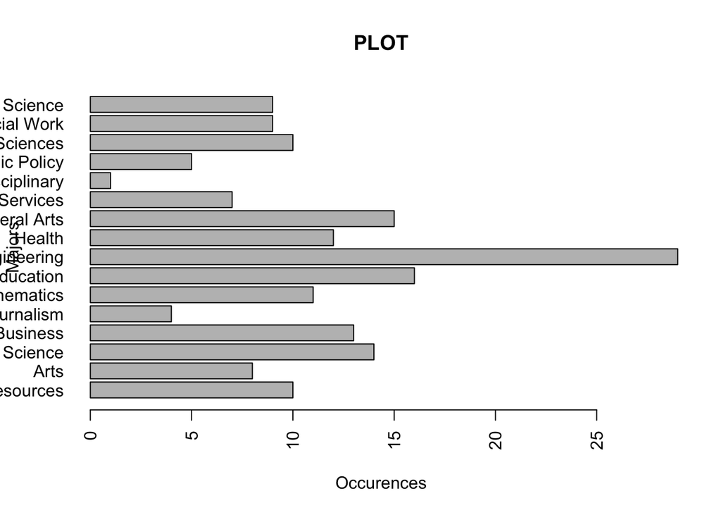

```r
major_count <- table(df$major_category)
par(las=2)
barplot(major_count, main="PLOT", horiz=TRUE, xlab = "Occurences", ylab = "Majors")
```

Easier way to do this with ggplot as it will do the counts for you

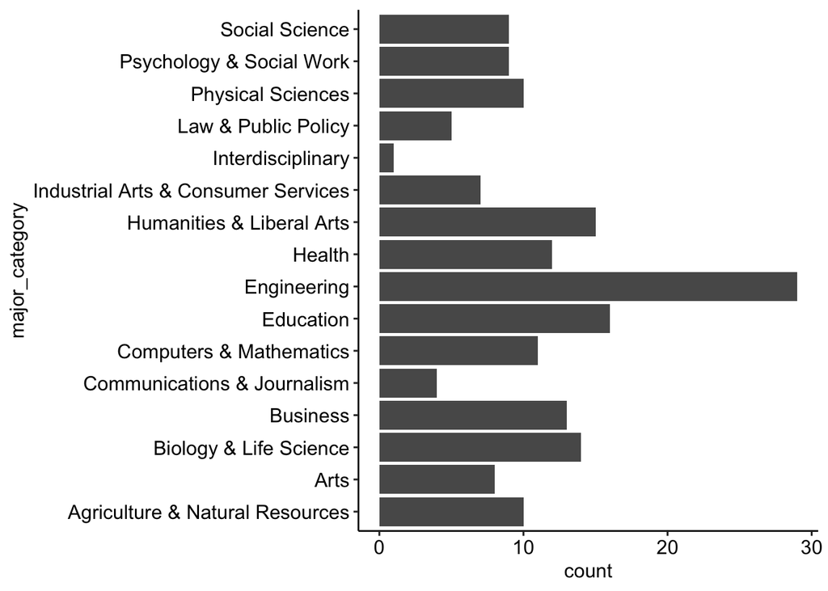

```r
g <- ggplot(df, aes(major_category))
g + geom_bar(position = position_stack(reverse = TRUE)) +
  coord_flip()
```

### 5d

Write the fivethirtyeight data to a csv file. Make sure that it does not have row labels

```r
write.csv(df,'college_recent_grads.csv', row.names = FALSE)
```

### 6. Codebook

My repository was created on [GitHub](https://github.com/jth1911/SMU-DS-6306)

If the link doesn’t work please copy and paste into your browser: https://github.com/jth1911/SMU-DS-6306